# Soil particulate organic C inputs and burial in a Midwest USA floodplain in the watershed of an intensively managed landscape

AGU Abstract #: EP41D-1239

Annie Edwards, annieedwards2025@u.northwestern.edu

Presented: Thursday, 12 December 2024; 08:30 - 12:20

# Methods

### Re-arranging the mixing equations to determine $\delta^13\textrm{C}$ of the reactive and unreactive input components

Begin with a two-component mixture (the reactive and unreactive components of organic C) applied to the standard mass-balance equations:

$$\begin{align}
\delta^{13}\textrm{C}_{ \textrm{floodplain}}\cdot\textrm{
%C}_\textrm{floodplain}&=\delta^{13}\textrm{C}_{
\textrm{reactive}}\cdot\textrm{
%C}_\textrm{reactive}+\delta^{13}\textrm{C}_{
\textrm{unreactive}}\cdot\textrm{ %C}_\textrm{unreactive} \tag{1}\\
\textrm{ %C}_\textrm{floodplain}&=\textrm{
%C}_\textrm{reactive}+\textrm{ %C}_\textrm{unreactive}\tag{2}\\
\end{align}$$
which can be combined and re-arranged into

$$\begin{align}
\delta^{13}\textrm{C}_{ \textrm{f}}\cdot\textrm{
%C}_\textrm{f}&=\delta^{13}\textrm{C}_{ \textrm{r}}\cdot\textrm{
%C}_\textrm{f}+\textrm{ %C}_\textrm{r}(\delta^{13}\textrm{C}_{
\textrm{u}}-\delta^{13}\textrm{C}_{ \textrm{r}}) \tag{3}\\
\end{align}$$
By plotting $\delta^13\textrm{C}_\textrm{f}\cdot \textrm{ %C}_\textrm{f}$ as a function of $\textrm{ %C}_\textrm{f}$, the linear relationship has slope $\delta^13\textrm{C}_\textrm{r}$, and the intercept can be solved for $\delta^13\textrm{C}_\textrm{u}$

Note: since the x and y of the graph are dependent on each other, this equation only works because we are confident that we see a clear two end-member mixing realtionship between $\delta^{13}\textrm{C}$ and $\textrm{ %C}$ through other means of validation.

### C-Burial Flux Calculations

C-burial flux calculations were determined with the following equations:

$$\begin{align}
\textrm{f}_\textrm{reactive}&=\frac{ \delta^{13}\textrm{C}_{
\textrm{f}}-\delta^{13}\textrm{C}_{ \textrm{u}}}{
\delta^{13}\textrm{C}_{ \textrm{r}}-\delta^{13}\textrm{C}_{ \textrm{u}}}
\tag{5}\\
\textrm{C}_\textrm{reactive burial flux}&=\textrm{C}_\textrm{burial
flux}\cdot\textrm{f}_\textrm{reactive}\tag{6}\\
\textrm{C}_{ \textrm{unreactive burial
flux}}&=\textrm{C}_\textrm{buried}\cdot
(1-\textrm{f}_\textrm{reactive})\tag{7}
\end{align}$$
which evaluate the the rate of change of the reactive and unreactive components with depth, given a known accumulation rate which was calculated with fly ash geochronology.

# Results

### Organic carbon (OC) burial post European settlement

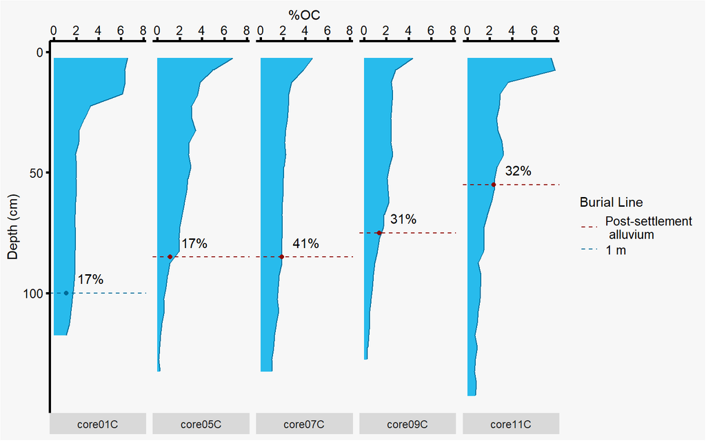

This indicates that there is some fraction of C likely being oxidized back into the atmosphere, while some fraction is buried long term (>100 years).

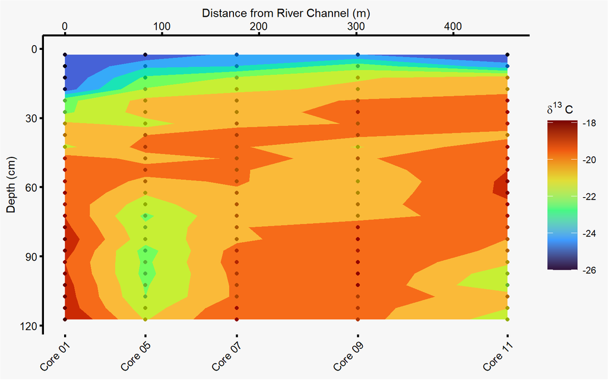

**Figure 4.** $\delta^{13}\textrm{C}$ variation with depth and distance from the river channel. **The change in isotopic values with depth indicates a change in source mixture.** There are more and less reactive components to the OC deposited to the floodplain.

### $\delta^{13}\textrm{C}$ ranges of floodplain inputs

| Core ID | Unreactive d13C | Reactive d13C |
| --- | --- | --- |
| Core01C | -17 | -28 |
| Core05C | -22 | -27 |
| Core07C | -19 | -28 |
| Core09C | -19 | -27 |
| Core11C | -18 | -29 |

The floodplain is located near intensively managed land. Upstream agriculture has included row-crop (corn-soybean, among others) rotations for at least the past 150 years, that have likely entered the alluvial system. Corn, a $\textrm{C}_4$ plant is isotopically distinct, with $\delta^{13}\textrm{C} \approx -10 \textrm{ to } -13‰$. **Unreactive C inputs are consistent with an alluvial mixture of** $\textrm{C}_3+\textrm{C}_4$ OC.

On the other hand, the old-growth forest located above the floodplain is dominated by $\textrm{C}_3$ plant sources, with $\delta^{13}\textrm{C} \approx -25 \textrm{ to } -35 ‰$. **Reactive C inputs are consistent with local ecosystem** $\textrm{C}_3$ OC.

### Carbon budgets for all cores in the floodplain

#### Core01C

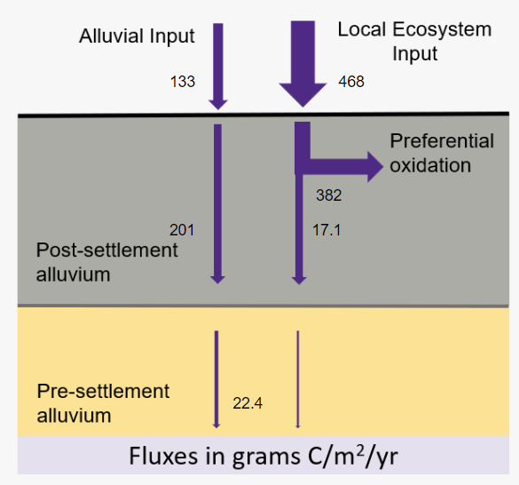

Figure 5

#### Core05C

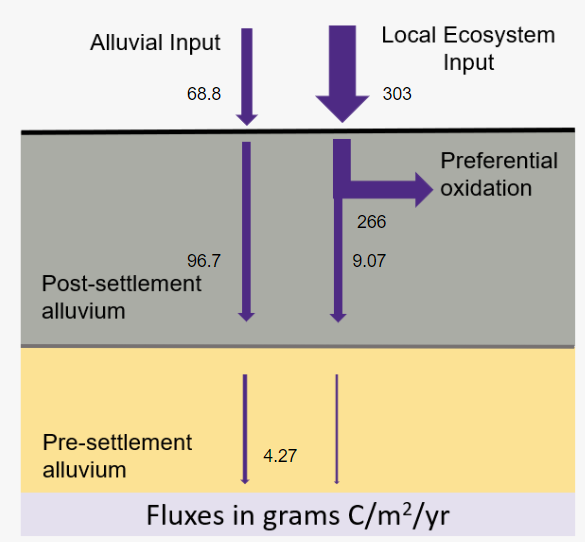

Figure 6

#### Core07C

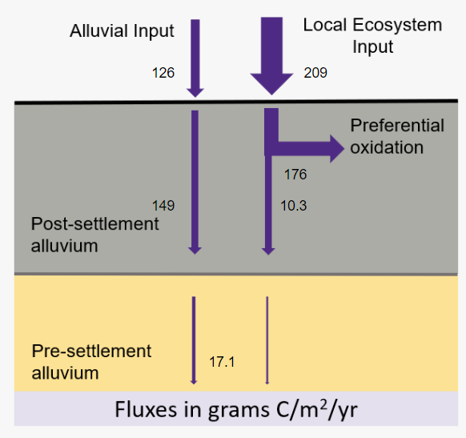

Figure 7

#### Core09C

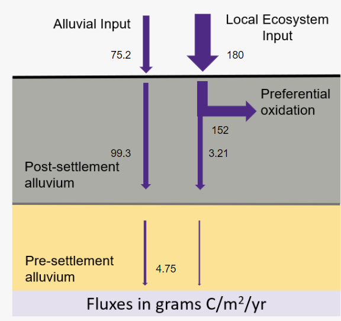

Figure 8

#### Core11C

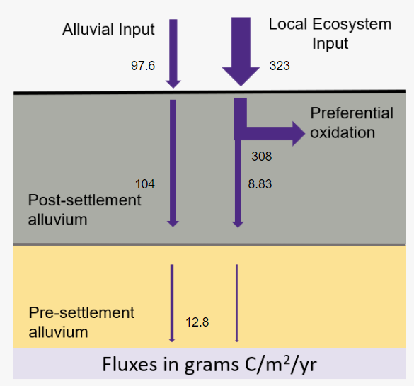

Figure 9

**Figures 5-9.** Modelled OC flux for all 5 floodplain cores with alluvial and ecosystem inputs, demonstrating the **preferential oxidation of the more reactive C from the local ecosystem, and subsequent long-term burial of unreactive, alluvially inputted OC.**